# STAT 4580 Homework 7

Anthony Cunningham

April 1, 2019

## Part 1: Cancellations and Destination Location

```
## # A tibble: 1 x 12
##   dest  n_cancelled n_flights perc_cancelled avg_arr_delay name    lat
##   <chr>       <int>     <int>          <dbl>         <dbl> <chr> <dbl>
## 1 SJU            14      1472        0.00951        -0.771 <NA>     NA
## # ... with 5 more variables: lon <dbl>, alt <int>, tz <dbl>, dst <chr>,
## #   tzone <chr>
```

It appears that the airport with destination code “SJU” in the flights table does not exist in the airports table, so we effectively have 49 airports with which we can plot on a map.

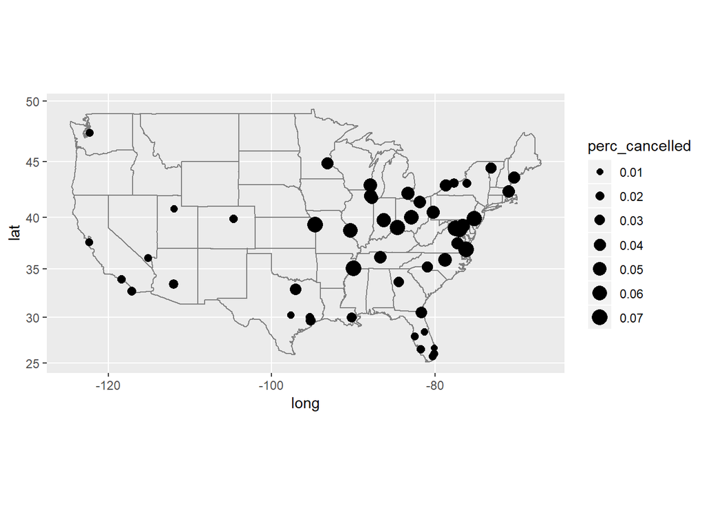

I notice that the proportion of cancelled flights tends to be greater in midwestern and northern locations. My intuition concurs, as these areas probably experience more inclimate weather, especially from January through March, leading to more cancellations of flights scheduled to travel to these airports.

Note: I discovered “case_when” function on Stack Overflow by user G. Grothendieck https://stackoverflow.com/questions/24459752/can-dplyr-package-be-used-for-conditional-mutating

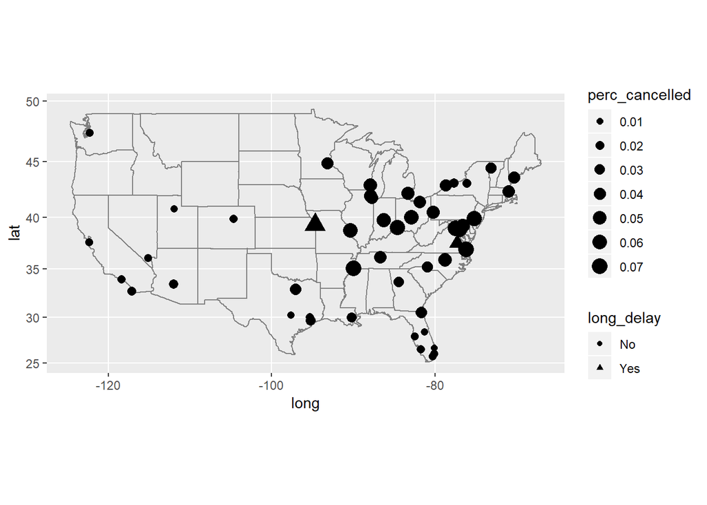

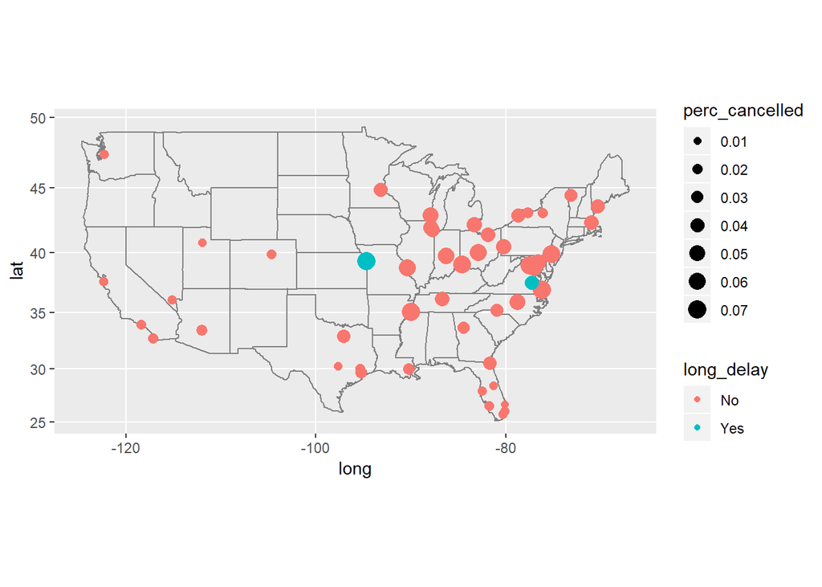

I prefer encoding the “long_delay” variable as color since the observations pop out a lot easier than when this variable is encoded using shape. The pop out is more pronounced in this data where only two observations differ from the rest, but using the color channel would still be more effective even if the two categories were more balanced in terms of the number of observations in each category. However, color is only effective in differentiating observations of different categories if the number of categories is smaller. If there are a large number of categories, then pop out will be less effective as there will be a greater chance of using two similar-looking colors. If we had a dataset in which we wanted to encode two categorical variables, then I would consider using shape to encode one of the variables. If given the choice, however, I would use color over shape, which is made clear in these two maps: shape is much harder to distinguish when all of the colors are the same, as well as with differering point sizes.

## Part 2: Wind Speed, Time of Day and Departure Delays

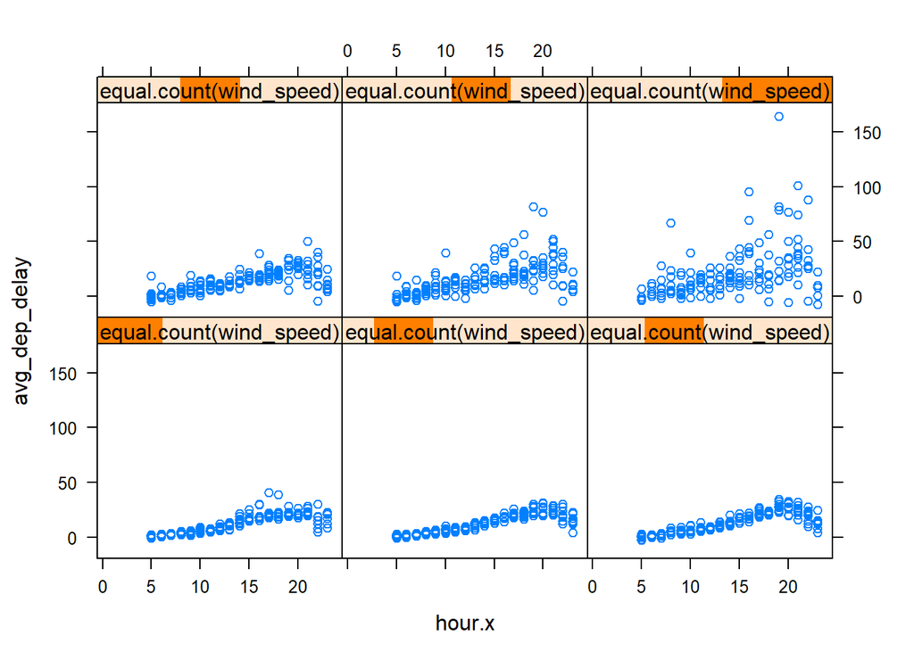

Regarless of wind speed, departure delays tend to increase the later in the day it is. As wind speeds increase, delay time tends to become more variable, particularly later in the day. This is consistent with our conclusion from Assignment 6, Part 3, in which departure delays tended to become more variable as wind speeds increased. After encoding the number of departures, there tended to be less flights departing at higher wind speeds, so part of this increased variation can be reflected by the lesser number of departing flights at higher wind speeds. This probably explains the greater variation at higher wind speeds in the Conditioning Plot shown above.